# Solving for Probabilistic Sensitivity Analysis Parameter Values

Transfinite Scaling for Stable Optimization

CEA

Authors

John Graves

Shawn Garbett

Hanxuan (Astrid) Yu

Jinyi Zhu

Ashley Leech

Published

November 21, 2023

## A Common Issue

- We have defined our underlying model (either from bottom up or through backwards conversion) but need to define PSA distributions for model parameters.
- Model draws on literature-based parameters that are reported as means, standard deviations, interquartile ranges, 95% confidence intervals, etc.

## A Common Issue

- Straightforward to obtain base case values from literature.
- But how can we define PSA distributions based on limited information?

## PSA Distributions

| Parameter Type | Distribution |
| --- | --- |
| Probability | beta |
| Rate | gamma |
| Utility weight | beta |
| Right skew (e.g., cost) | gamma, lognormal |
| Relative risks or hazard ratios | lognormal |
| Odds Ratio | logistic |

## Example

- Cost parameter reported in literature has interquartile range of $300-$750.
- What are the parameters of a PSA distribution such that the 25th percentile is $300 and the 75th percentile is $750?

## Some Options

- Analytic formulas for some distributions (normal, gamma, beta).
- Formulas take as their inputs the two values ($x_1$, $x_2$) and their associated quantiles ($p_1$,$p_2$).
- Formulas return the PSA distribution parameters that match up to these values.

## Some Options

- ParameterSolver implemented in Windows, [Link](https://biostatistics.mdanderson.org/SoftwareDownload/SingleSoftware/Index/6)
- See Cook (2010) and [Vasco Grilo’s blog post](https://forum.effectivealtruism.org/posts/tvTqRtMLnJiiuAep5/how-to-determine-distribution-parameters-from-quantiles) for more.
- The next few slides provide you with nearly all the tools you’ll need, however.

## Example: Cost PSA Distribution

- Suppose the interquartile range for a key cost variable is [300,750]
- We may have obtained this from the literature, from tabulating cost data, or from expert opinions.

## Example: Cost PSA Distribution

- Suppose the interquartile range for a key cost variable is [300,750]
- We may have obtained this from the literature, from tabulating cost data, or from expert opinions.

```r
x1 = 300
p1 = 0.25

x2 = 750
p2 = 0.75
```

## Analytic Solution: Uniform PSA

For a uniform distribution with minimum $a$ and maximum $b$

$$a = \frac{p_2x_1 - p_1x_2}{p_2-p_1}$$
$$b = \frac{(1-p_1)x_2-(1-p_2)x_1}{p_2-p_1}$$

## Analytic Solution: Uniform PSA

```r
a = ((p2*x1) - (p1 * x2)) / (p2 - p1)
a
```

```
[1] 75
```

```r
b = ((1 - p1)*x2 - (1 - p2)*x1) / (p2 - p1)
b
```

```
[1] 975
```

## Analytic Solution: Uniform PSA

```r
qunif(0.25, min = 75, max = 975)
```

```
[1] 300
```

```r
qunif(0.75, min = 75, max = 975)
```

```
[1] 750
```

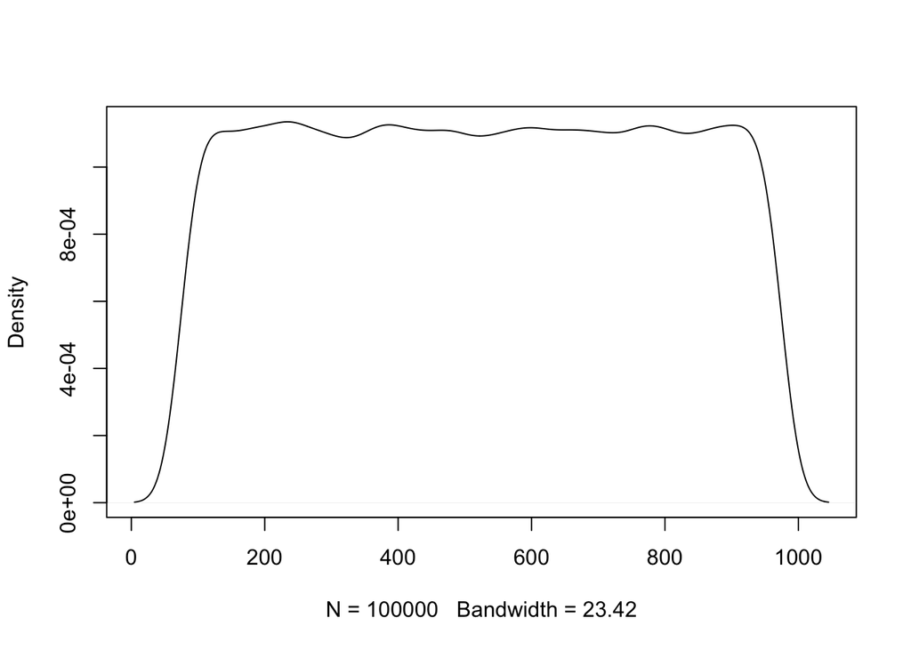

## Analytic Solution: Normal PSA

$$\sigma = \frac{x_2 - x_1}{\Phi^{-1}(p_2)-\Phi^{-1}(p_1)}$$

$$\mu = \frac{x_1\Phi^{-1}(p_2)-x_2\Phi^{-1}(p_1)}{\Phi^{-1}(p_2)-\Phi^{-1}(p_1)}$$

## Analytic Solution: Normal PSA

```r
mu = (qnorm(p2)*x1 - qnorm(p1)*x2) / (qnorm(p2)-qnorm(p1))
mu
```

```
[1] 525
```

```r
sigma = (x2 - x1) / (qnorm(p2) - qnorm(p1))
sigma
```

```
[1] 333.5855
```

## Analytic Solution: Normal PSA

```r
qnorm(0.25, mean = 525, sd = 333.59)
```

```
[1] 299.997
```

```r
qnorm(0.75, mean = 525, sd = 333.59)
```

```
[1] 750.003
```

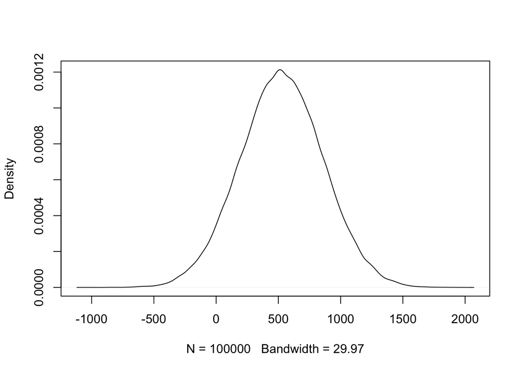

## Analytic Solution: Lognormal PSA

- Just take log of $x_1$ and $x_2$

$$\sigma = \frac{\ln(x_2) - \ln(x_1)}{\Phi^{-1}(p_2)-\Phi^{-1}(p_1)}$$

$$\mu = \frac{\ln(x_1)\Phi^{-1}(p_2)-\ln(x_2)\Phi^{-1}(p_1)}{\Phi^{-1}(p_2)-\Phi^{-1}(p_1)}$$

## Analytic Solution: Lognormal PSA

```r
mu = (qnorm(p2)*log(x1) - qnorm(p1)*log(x2)) / (qnorm(p2)-qnorm(p1))
mu
```

```
[1] 6.161928
```

```r
sigma = (log(x2) - log(x1)) / (qnorm(p2) - qnorm(p1))
sigma
```

```
[1] 0.6792473
```

## Analytic Solution: Lognormal PSA

```r
qlnorm(0.25, mean = 6.1619, sd = 0.67925)
```

```
[1] 299.9911
```

```r
qlnorm(0.75, mean = 6.1619, sd = 0.67925)
```

```
[1] 749.9805
```

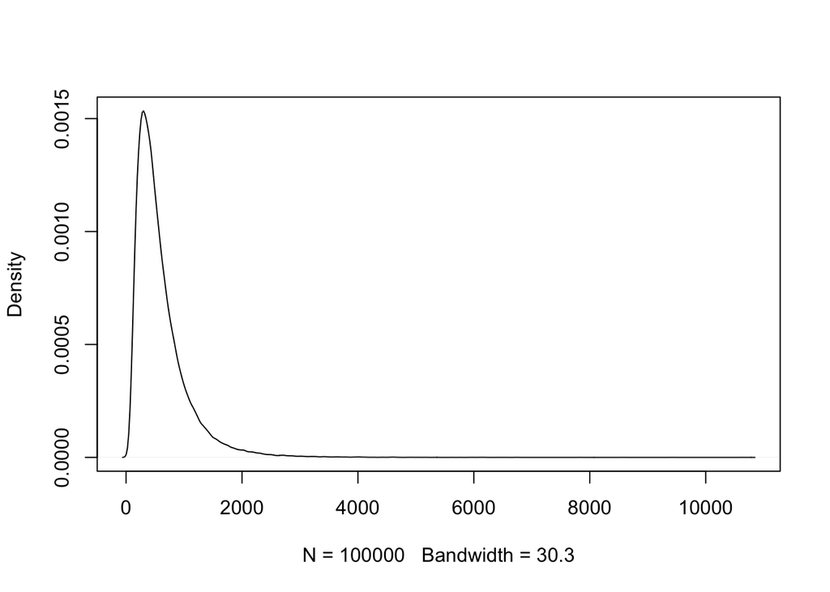

## Analytic Solution: Gamma PSA

- A bit more involved as it involves finding the root of a function.

## Analytic Solution: Gamma PSA

- A bit more involved as it involves finding the root of a function.

```r
gamma_fn <- function(alpha) {
    x1*qgamma(p2,shape = alpha, scale =1) - x2 * qgamma(p1, shape = alpha, scale = 1)
}
curve(gamma_fn, xlim = c(1,10), col = "blue", lwd = 1.5, lty=2)
abline(a=0,b=0)
```

[output not shown]

## Analytic Solution: Gamma PSA

```r
gamma_fn <- function(alpha) {
    x1*qgamma(p2,shape = alpha, scale =1) - x2 * qgamma(p1, shape = alpha, scale = 1)
}
curve(gamma_fn, xlim = c(1,10), col = "blue", lwd = 1.5, lty=2)
abline(a=0,b=0)
```

[output not shown]

## Analytic Solution: Gamma PSA

- We’ll search in this range for our $\alpha$ value.

```r
gamma_fn <- function(alpha) {
    x1*qgamma(p2,shape = alpha, scale =1) - x2 * qgamma(p1, shape = alpha, scale = 1)
}
curve(gamma_fn, xlim = c(1,10), col = "blue", lwd = 1.5, lty=2)
abline(a=0,b=0)
```

[output not shown]

## Analytic Solution: Gamma PSA

```r
alpha_ <- uniroot(gamma_fn,c(2,4))$root
alpha_
```

```
[1] 2.455801
```

```r
calc_beta <- function(x1,p1,alpha) {
    x1 / qgamma(p1,alpha,1)
}

beta_ <- calc_beta(x1 = x1,  p1 = p1, alpha = alpha_)
beta_
```

```
[1] 230.1627
```

## Analytic Solution: Gamma PSA

```r
qgamma(0.25,shape = 2.4558, scale = 230.16)
```

```
[1] 299.9963
```

```r
qgamma(0.75,shape = 2.4558, scale = 230.16)
```

```
[1] 749.9956
```

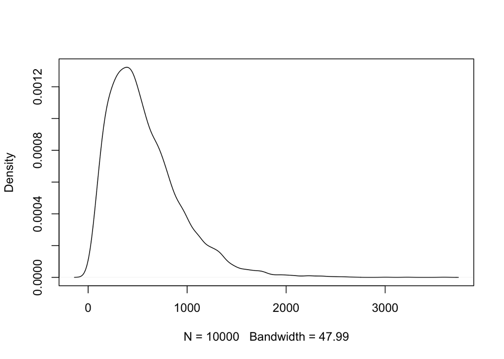

## Alternative: Optimization

- General solution that can be used to solve for parameters of many common PSA distributions (e.g., beta, gamma, etc.).

$$\min_{\vec{\theta} \in R}\,\, (F(x_1|\vec{\theta})-p_1)^2+(F(x_2|\vec{\theta})-p_2)^2$$

## Alternative: Optimization

- Requires cumulative distribution function (CDF), $F$.
- See Hans W Borchers’ [great slides](https://hwborchers.lima-city.de/Presents/ROptimSlides4.pdf) for tips on optimization in R.

## Some Advice

- We have found that while analytically correct, this optimization formula is not numerically stable.
- Transfinite scaling of the probabilities from CDFs $F(.)$ stabilizes optimization.

## Some Advice

- We have found that while analytically correct, this optimization formula is not numerically stable.
- Transfinite scaling of the probabilities from CDFs $F(.)$ stabilizes optimization.
- $g(F(.))$ vs. $F(.)$

$$\min_{\vec{\theta} \in R}\,\, (g(F(x_1|\vec{\theta}))-p_1)^2+(g(F(x_2|\vec{\theta}))-p_2)^2$$

## Stable Optimization

- For probabilities, this is the $\text{logit}(p)=\log \frac{p}{1-p}=\log p - \log (1-p)$.
- Tweaking parameters to converge can still happen.
- Example of theory versus practice.

## Stable Optimization

- For probabilities, this is the $\text{logit}(p)=\log \frac{p}{1-p}=\log p - \log (1-p)$.
- Tweaking parameters to converge can still happen.
- Example of theory versus practice.

$$\min_{\vec{\theta} \in R} \sum_{i \in 1,2}\,\, (\text{logit} (F(x_i|\vec{\theta}))-\text{logit} (p_i))^2$$

## Transfinite Example, Part 1

```r
# Transfinite scaling
Tf <- function(x, shape, rate)
    pgamma(x,shape,rate,log=TRUE) -
    pgamma(x,shape,rate,log=TRUE, lower.tail = FALSE)

# Function to minimize
norm <- function(x1, p1, x2, p2, shape,rate)
    (Tf(x1, shape, rate)-(log(p1)-log(1-p1)) )^2 +
    (Tf(x2, shape, rate)-(log(p2)-log(1-p2)) )^2

# Bundle it all together into a single function.
fn <- function(x) norm(x1, p1, x2, p2, x[1], x[2])
```

## Transfinite Example, Part 2

```r
# Run general-purpose optimization on the function.
gamma_optim <-
  optim(c(0.5, 0.1), # initial parameter guesses
    fn,
    gr = function(x) pracma::grad(fn, x),
    lower=c(-Inf, 1e-5),
    method = "L-BFGS-B",
    control=list(factr=1e-10, maxit=100))$par

# Note: gamma_optim$par[2] is 1/beta
gamma_optim
```

```
[1] 2.455855553 0.004344879
```

## Transfinite Example

- Optimization returns $\alpha$ and $1/\beta$ for the gamma distribution example.

```r
# Analytic formula
alpha_
```

```
[1] 2.455801
```

```r
# Optimization
gamma_optim[[1]]
```

```
[1] 2.455856
```

```r
# Analytic formula
beta_
```

```
[1] 230.1627
```

```r
# Optimization
1/gamma_optim[[2]]
```

```
[1] 230.156
```

## Optimization for Other Distributions

- Just swap in the distribution function for the distribution you want to match to (e.g., `pbeta` rather than `pgamma`).
- Also make sure the supplied parameter names match the distribution you’re aiming for.

## Optimization for Other Distributions

- Just swap in the distribution function for the distribution you want to match to (e.g., `pbeta` rather than `pgamma`).
- Also make sure the supplied parameter names match the distribution you’re aiming for.

```r
Tf <- function(x, shape, rate)
    pgamma(x,shape,rate,log=TRUE) -
    pgamma(x,shape,rate,log=TRUE, lower.tail = FALSE)
```

## Optimization for Other Distributions

- Just swap in the distribution function for the distribution you want to match to (e.g., `pbeta` rather than `pgamma`).
- Also make sure the supplied parameter names match the distribution you’re aiming for.

```r
Tf <- function(x, shape, rate)
    pgamma(x,shape,rate,log=TRUE) -
    pgamma(x,shape,rate,log=TRUE, lower.tail = FALSE)
```

## A Web-Based Shiny Tool

https://yuhanxuan.shinyapps.io/shiny4dist/

Author: Hanxuan (Astrid) Yu

[figure not shown]

## Summary on Distribution Fitting

- Use analytical formulas if they exist.
- Optimize on $\text{logit}$ scale.
- Again, avoid $\log$ on probabilities, use `log=TRUE`.
- Plot results for visual check.

## References

Cook, John D. 2010. “Determining Distribution Parameters from Quantiles.” Working paper.